# 钻石数据的探索性数据分析（R） by Batu Mengkai

## 1.简介

此diamonds数据集包含了从diamondsc.info网站收集的自2008年到现在的53940颗钻石的信息。钻石的独特性，与我们常买的制造产品不同，你不能只根据一个型号就能看到价格。下面我将分别探索该数据集的单一变量，两个变量以及多个变量,从而发现钻石的特征与价格之间的关系。

### 数据描述

- carat：克拉
- cut：切割质量（Fair, Good, Very Good, Premium, Ideal）
- color：颜色等级（J (最差), I, H, G, F, E, D (最好)）
- clarity：纯净度等级（I1 (最差), SI2, SI1, VS2, VS1, VVS2, VVS1, IF (最好)）
- depth：深度比例 （depth = z / mean(x, y) = 2 * z / (x + y) (43–79)）
- table：钻石顶部相对于最宽点的宽度 (43–95)
- price：价格in m美元 (326–18,823)
- “x” “y” “z” ：长宽深 mm

```r
library(ggplot2)
data(diamonds)
str(diamonds)
```

```
## Classes 'tbl_df', 'tbl' and 'data.frame':    53940 obs. of  10 variables:
##  $ carat  : num  0.23 0.21 0.23 0.29 0.31 0.24 0.24 0.26 0.22 0.23 ...
##  $ cut    : Ord.factor w/ 5 levels "Fair"<"Good"<..: 5 4 2 4 2 3 3 3 1 3 ...
##  $ color  : Ord.factor w/ 7 levels "D"<"E"<"F"<"G"<..: 2 2 2 6 7 7 6 5 2 5 ...
##  $ clarity: Ord.factor w/ 8 levels "I1"<"SI2"<"SI1"<..: 2 3 5 4 2 6 7 3 4 5 ...
##  $ depth  : num  61.5 59.8 56.9 62.4 63.3 62.8 62.3 61.9 65.1 59.4 ...
##  $ table  : num  55 61 65 58 58 57 57 55 61 61 ...
##  $ price  : int  326 326 327 334 335 336 336 337 337 338 ...
##  $ x      : num  3.95 3.89 4.05 4.2 4.34 3.94 3.95 4.07 3.87 4 ...
##  $ y      : num  3.98 3.84 4.07 4.23 4.35 3.96 3.98 4.11 3.78 4.05 ...
##  $ z      : num  2.43 2.31 2.31 2.63 2.75 2.48 2.47 2.53 2.49 2.39 ...
```

```r
summary(diamonds)
```

```
##      carat               cut        color        clarity
##  Min.   :0.2000   Fair     : 1610   D: 6775   SI1    :13065
##  1st Qu.:0.4000   Good     : 4906   E: 9797   VS2    :12258
##  Median :0.7000   Very Good:12082   F: 9542   SI2    : 9194
##  Mean   :0.7979   Premium  :13791   G:11292   VS1    : 8171
##  3rd Qu.:1.0400   Ideal    :21551   H: 8304   VVS2   : 5066
##  Max.   :5.0100                     I: 5422   VVS1   : 3655
##                                     J: 2808   (Other): 2531
##      depth           table           price             x
##  Min.   :43.00   Min.   :43.00   Min.   :  326   Min.   : 0.000
##  1st Qu.:61.00   1st Qu.:56.00   1st Qu.:  950   1st Qu.: 4.710
##  Median :61.80   Median :57.00   Median : 2401   Median : 5.700
##  Mean   :61.75   Mean   :57.46   Mean   : 3933   Mean   : 5.731
##  3rd Qu.:62.50   3rd Qu.:59.00   3rd Qu.: 5324   3rd Qu.: 6.540
##  Max.   :79.00   Max.   :95.00   Max.   :18823   Max.   :10.740
##
##        y                z
##  Min.   : 0.000   Min.   : 0.000
##  1st Qu.: 4.720   1st Qu.: 2.910
##  Median : 5.710   Median : 3.530
##  Mean   : 5.735   Mean   : 3.539
##  3rd Qu.: 6.540   3rd Qu.: 4.040
##  Max.   :58.900   Max.   :31.800
##
```

## 2.探索单一变量

### 2.1 价格分布

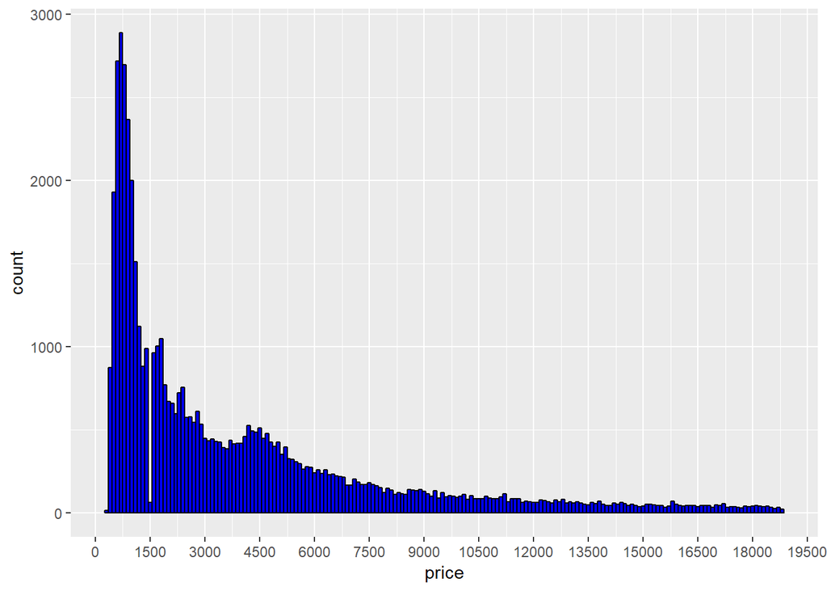

```r
ggplot(data = diamonds, aes(x = price))+
  geom_histogram(binwidth = 100, color = "black", fill = "blue")+
  scale_x_continuous(breaks = seq(0,20000,1500))
```

```r
summary(diamonds$price)
```

```
##    Min. 1st Qu.  Median    Mean 3rd Qu.    Max.
##     326     950    2401    3933    5324   18823
```

**探索分析：**

**价格进行log10数据转化**

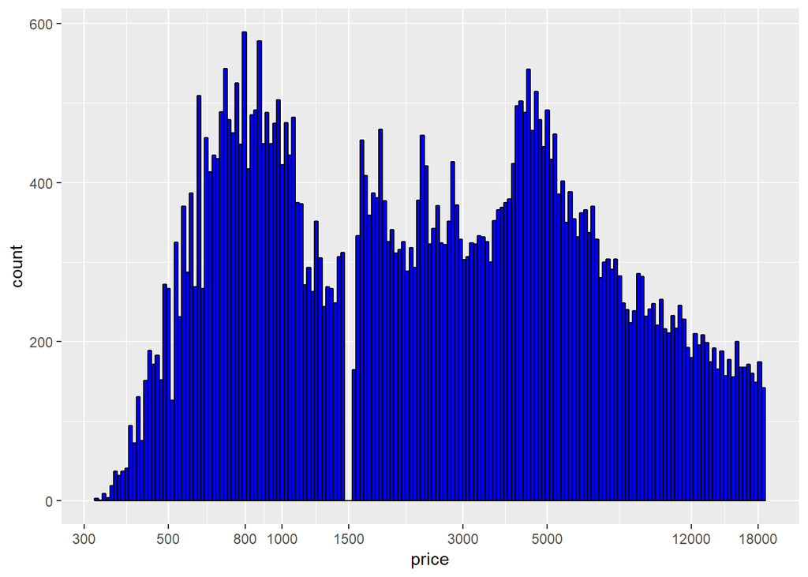

```r
ggplot(data = diamonds, aes(x = price))+
  geom_histogram(binwidth = 0.01,color = "black", fill = "blue")+
  scale_x_log10(breaks = c(300,500,800,1000,1500,3000,5000,12000,18000))
```

**探索分析：**

- 对价格进行log10转化后，发现分布是双峰分布，可能是对于不同消费量级的群体，价格接受程度不同，高消费人群中价格5000左右的钻石是卖的最多，在低消费人群中价格800左右的钻石卖的最多。

### 2.2查看克拉carat分布情况

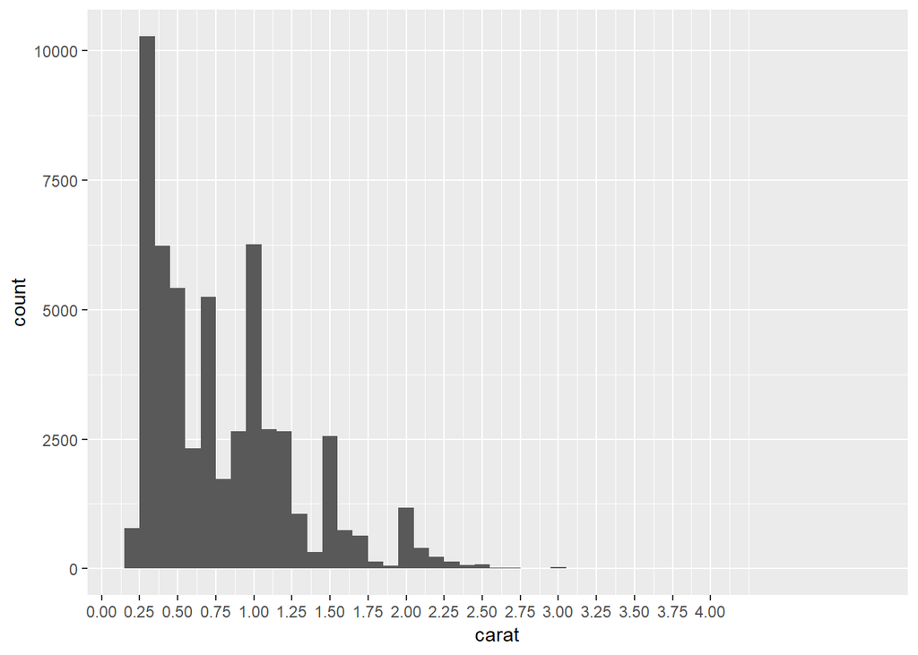

```r
ggplot(data = diamonds, aes(x = carat))+
  geom_histogram(binwidth = 0.1)+
  scale_x_continuous(breaks = seq(0,4,0.25))
```

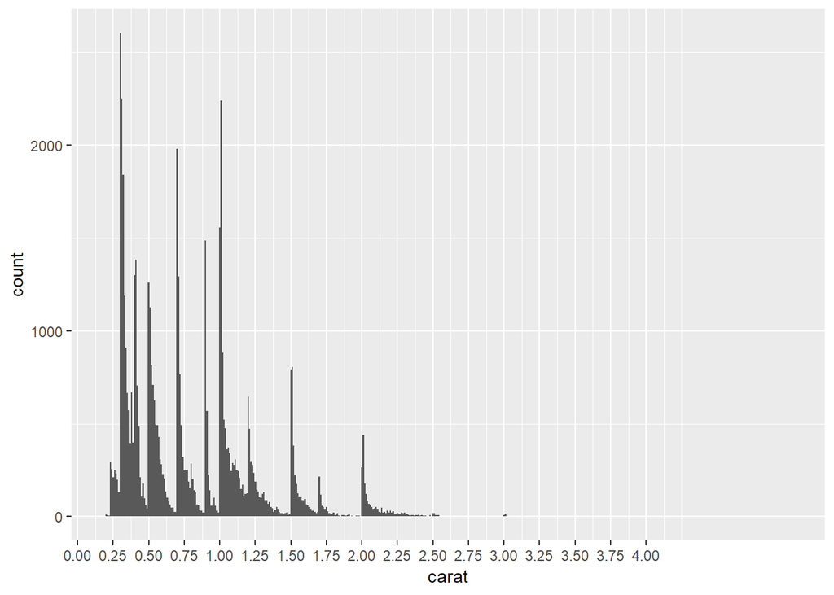

```r
ggplot(data = diamonds, aes(x = carat))+
  geom_histogram(binwidth = 0.01)+
  scale_x_continuous(breaks = seq(0,4,0.25))
```

```r
summary(diamonds$carat)
```

```
##    Min. 1st Qu.  Median    Mean 3rd Qu.    Max.
##  0.2000  0.4000  0.7000  0.7979  1.0400  5.0100
```

```r
sort(table(diamonds$carat),decreasing = TRUE)[1:20]
```

```
##
##  0.3 0.31 1.01  0.7 0.32    1  0.9 0.41  0.4 0.71  0.5 0.33 0.51 0.34 1.02
## 2604 2249 2242 1981 1840 1558 1485 1382 1299 1294 1258 1189 1127  910  883
## 0.52 1.51  1.5 0.72 0.53
##  817  807  793  764  709
```

**探索分析：**

- 钻石重量最小是0.2克拉，最大是5.01克拉，75%的钻石是小于1.04克拉，从第一个图上按0.1分布看，钻石呈现右偏态，从第二个图按0.01分布看，钻石在特定尺寸出现分布峰值

### 2.3 查看不同切割质量(cut)分布

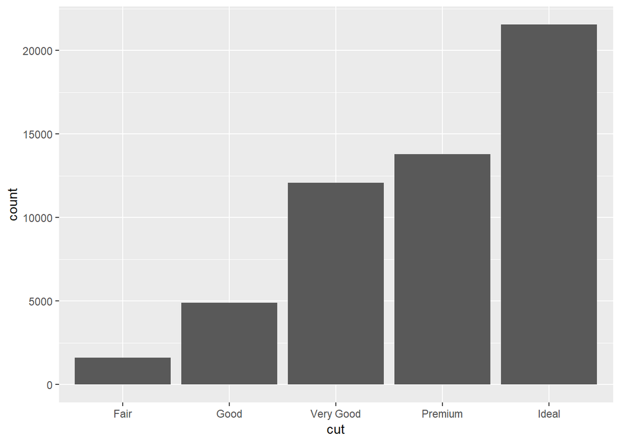

```r
ggplot(data = diamonds, aes(x = cut))+
  geom_bar()
```

```r
table(diamonds$cut)
```

```
##
##      Fair      Good Very Good   Premium     Ideal
##      1610      4906     12082     13791     21551
```

**探索分析：**

- 钻石切割质量是最差到最好的等级是（Fair, Good, Very Good, Premium, Ideal）
- 从上图的描述统计和条形图可以看出，数量上切割质量为ideal的最多，其次是premium和very good级别的

### 2.3 查看不同颜色质量的钻石数据分布

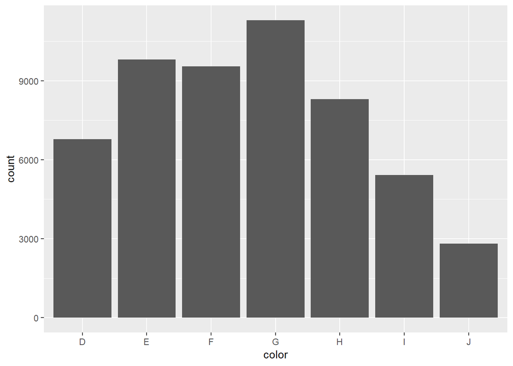

```r
ggplot(data = diamonds, aes(x = color))+
  geom_bar()
```

```r
table(diamonds$color)
```

```
##
##     D     E     F     G     H     I     J
##  6775  9797  9542 11292  8304  5422  2808
```

**探索分析：**

- 颜色质量J (最差), I, H, G, F, E, D (最好)
- 颜色质量为G的钻石数量最多
- 其次是颜色为EFH的钻石

### 2.4 查看不同纯净度的钻石数据分布

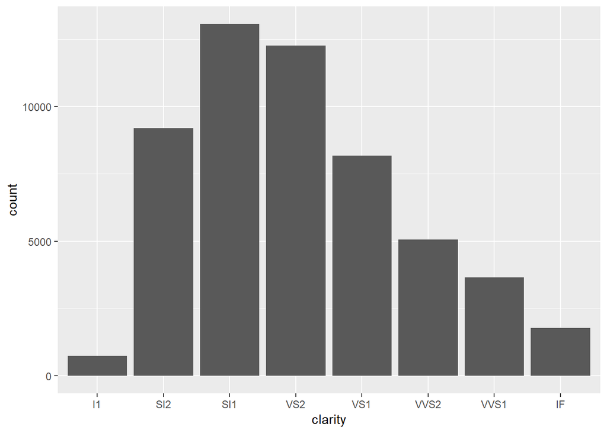

```r
ggplot(data = diamonds, aes(x=clarity))+
  geom_bar()
```

```r
table(diamonds$clarity)
```

```
##
##    I1   SI2   SI1   VS2   VS1  VVS2  VVS1    IF
##   741  9194 13065 12258  8171  5066  3655  1790
```

**探索分析：**

- clarity纯净度等级I1 (最差), SI2, SI1, VS2, VS1, VVS2, VVS1, IF (最好)
- 从上面的分布图可以看出，纯净度质量高的钻石数量相比纯净度质量低的数量要少
- 纯净度质量为SI1,VS2的钻石数量最多，其次是SI2,VS1

### 2.5 查看钻石尺寸数据的分布

#### x,y,z（钻石长、宽、深）尺寸的分布

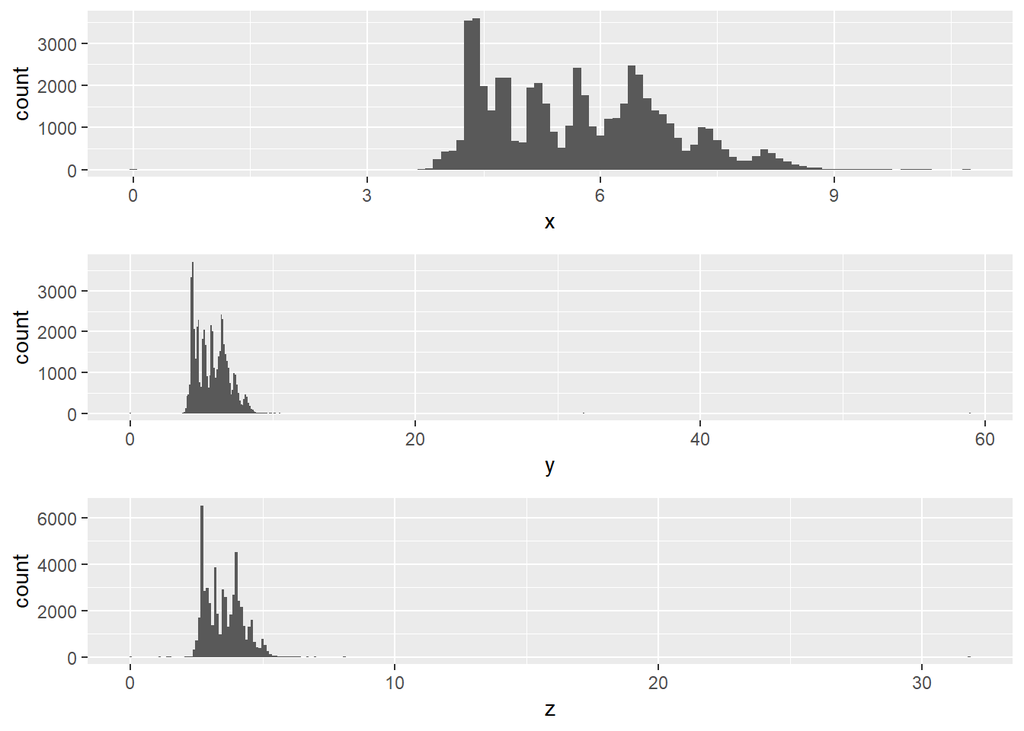

```r
p1<- ggplot(data = diamonds, aes(x = x))+
  geom_histogram(binwidth = 0.1)
p2<- ggplot(data = diamonds, aes(x = y))+
  geom_histogram(binwidth = 0.1)
p3<- ggplot(data = diamonds, aes(x = z))+
  geom_histogram(binwidth = 0.1)

library(gridExtra)
grid.arrange(p1,p2,p3, ncol=1 )
```

由于y,z有异常值，我们现在显示数据集中部分

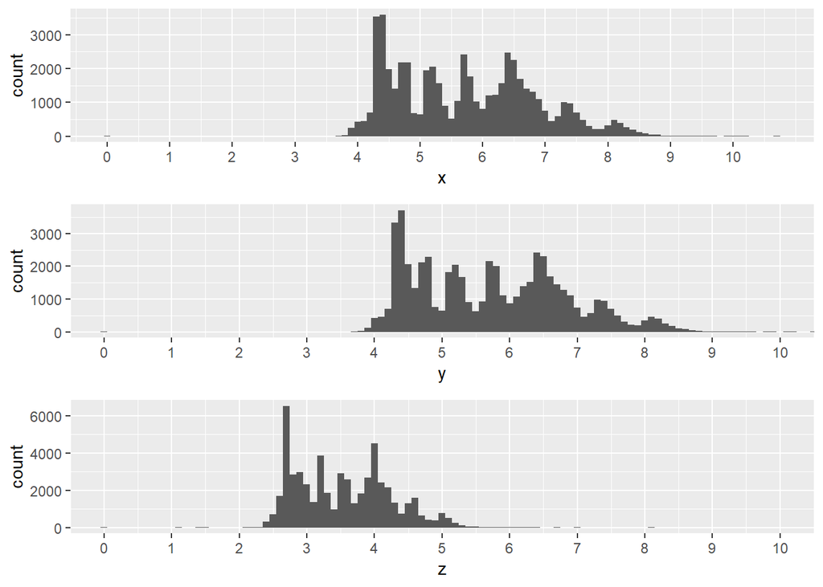

```r
p1<- ggplot(data = diamonds, aes(x = x))+
  geom_histogram(binwidth = 0.1)+
  scale_x_continuous(breaks = seq(0,10,1))
p2<- ggplot(data = diamonds, aes(x = y))+
  geom_histogram(binwidth = 0.1)+
  scale_x_continuous(breaks = seq(0,10,1))+
  coord_cartesian(xlim = c(0,10))

p3<- ggplot(data = diamonds, aes(x = z))+
  geom_histogram(binwidth = 0.1)+
  scale_x_continuous(breaks = seq(0,10,1))+
  coord_cartesian(xlim = c(0,10))

library(gridExtra)
grid.arrange(p1,p2,p3, ncol=1 )
```

**探索分析：**

- 从上图可以看出，钻石长度x范围主要在4-9mm, 钻石宽度y范围在4-9mm,钻石深度z范围在2-5.5mm

#### 钻石深度比例depth分布

深度比例公式：depth = z / mean(x, y) = 2 * z / (x + y) (43–79)

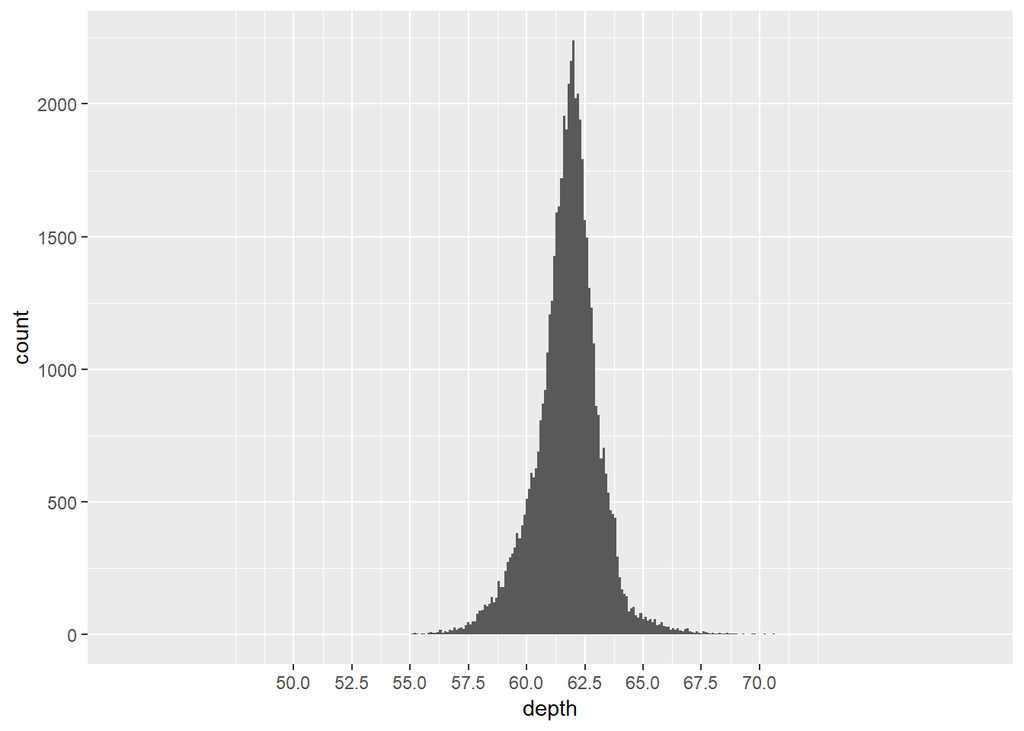

```r
ggplot(data = diamonds, aes(x = depth))+
  geom_histogram(binwidth = 0.1)+
  scale_x_continuous(breaks = seq(50,70,2.5))
```

```r
summary(diamonds$depth)
```

```
##    Min. 1st Qu.  Median    Mean 3rd Qu.    Max.
##   43.00   61.00   61.80   61.75   62.50   79.00
```

**探索分析：**

#### 钻石table值的分布

table是钻石顶部相对于最宽点的宽度 (范围43–95)

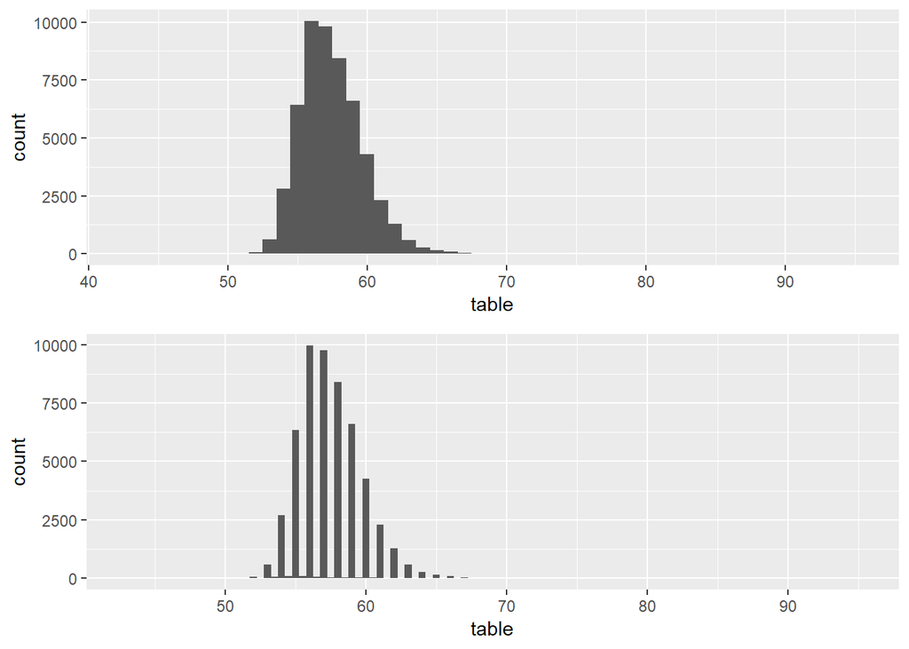

```r
p1<- ggplot(data = diamonds, aes(x = table))+
  geom_histogram(binwidth = 1)

p2<- ggplot(data = diamonds, aes(x = table))+
  geom_histogram(binwidth = 0.5)

grid.arrange(p1,p2,ncol = 1)
```

```r
sort(table(diamonds$table),decreasing = TRUE)[1:20]
```

```
##
##   56   57   58   59   55   60   54   61   62   63   53   64   65   66   52
## 9881 9724 8369 6572 6268 4241 2594 2282 1273  588  567  260  146   91   56
##   67 54.1 55.1 53.9 54.2
##   42   30   30   28   28
```

**探索分析：**

- table按照宽度1分布，呈现正态分布，将宽度调整为0.5,发现数据呈现离散情况，根据table各值统计情况看，table值主要集中在52-67的整数上

### 2.6 通过对单一变量分析得到以下总结：

1. 价格分布呈现右偏态，50%的钻石价格小于2401美元，75%的钻石价格小于5324美元
2. 75%的钻石重量小于1.04克拉
3. 切割质量等级ideal的钻石最多，其次是premium和very good
4. 大多数钻石颜色等级是在G或比G更高的等级
5. 大多数钻石纯净度在SI2,SI1,VS2,VS1水平，纯净度SI1的钻石最多